# MZES SSDL: Computationally Analyzing Politicians’ Body Language Using Pose Estimation

Oliver Rittmann

October 16, 2024

# Load movenet prediction output (pose estimation) into R

The pose estimation data comes in .json format. We have two files, one for each video.

```r
files <- list.files(here("movenet_results"))

json_files <- files[str_detect(files, ".json")]

json_files
```

```
## [1] "speech1_gabriela_heinrich.json" "speech2_klaus_ernst.json"
```

Let’s have a look at how the data looks like

```r
speech1_raw <- jsonlite::fromJSON(paste0("movenet_results/", json_files[1]))
speech2_raw <- jsonlite::fromJSON(paste0("movenet_results/", json_files[2]))

#head(speech1_raw)
dim(speech1_raw)
```

```
## [1] 274   1   1  17   3
```

```r
dim(speech2_raw)
```

```
## [1] 267   1   1  17   3
```

Dimensions 274 x 1 x 1 x 17 x 3 – Any ideas what these dimensions are about?

```r
# the first frame
speech1_raw[1,,,,]
```

```
##            [,1]      [,2]       [,3]
##  [1,] 0.3828655 0.5242524 0.68463719
##  [2,] 0.3538715 0.5414523 0.75235844
##  [3,] 0.3582214 0.5031287 0.48237407
##  [4,] 0.3297369 0.5690745 0.69024754
##  [5,] 0.3400428 0.4759488 0.75820732
##  [6,] 0.3940416 0.6355466 0.90980828
##  [7,] 0.4116655 0.4349169 0.86186630
##  [8,] 0.5216534 0.6782555 0.78337336
##  [9,] 0.5355401 0.3803662 0.79445451
## [10,] 0.6526011 0.6498522 0.74373788
## [11,] 0.6306298 0.3373373 0.71716160
## [12,] 0.6974007 0.6186860 0.67185098
## [13,] 0.6894653 0.4781892 0.77422142
## [14,] 0.5340295 0.6774333 0.02469357
## [15,] 0.7561160 0.4362402 0.02170779
## [16,] 0.7344654 0.5591633 0.01254712
## [17,] 0.7249266 0.4822194 0.01522222
```

```r
# the second frame
speech1_raw[2,,,,]
```

```
##            [,1]      [,2]       [,3]
##  [1,] 0.3862496 0.5251055 0.67808115
##  [2,] 0.3568694 0.5423815 0.66246796
##  [3,] 0.3613199 0.5044520 0.63965297
##  [4,] 0.3316347 0.5683912 0.71318316
##  [5,] 0.3397953 0.4757831 0.76745760
##  [6,] 0.3932600 0.6335180 0.92080253
##  [7,] 0.4108571 0.4332503 0.86009669
##  [8,] 0.5208964 0.6780418 0.76514769
##  [9,] 0.5338422 0.3806624 0.79595304
## [10,] 0.6529879 0.6426720 0.70536762
## [11,] 0.6289278 0.3394258 0.74657613
## [12,] 0.6980432 0.6165766 0.63646030
## [13,] 0.6903628 0.4749334 0.76130944
## [14,] 0.5327339 0.6781441 0.02760529
## [15,] 0.7528221 0.4366665 0.01941576
## [16,] 0.7332112 0.5591093 0.01317525
## [17,] 0.7237307 0.4805307 0.01731255
```

The first two columns of the last dimension represents the y- and x- coordinates (normalized to image frame, i.e. range in [0.0, 1.0]) of the 17 keypoints:

- 1 nose
- 2 left eye
- 3 right eye
- 4 left ear
- 5 right ear
- 6 left shoulder
- 7 right shoulder
- 8 left elbow
- 9 right elbow
- 10 left wrist
- 11 right wrist
- 12 left hip
- 13 right hip
- 14 left knee
- 15 right knee
- 16 left ankle
- 17 right ankle

The third column tells us how confident the model was in its detection, with confidence scores ranging between 0 and 1.

# Organize pose estimation data

Let’s bring this data into a format that makes it easier to work with.

```r
array_to_timeseries <- function(data_list,
                                file_name,
                                video_length){
  ts_dat <-
    data.frame(file_name = rep(file_name, dim(data_list)[1]),
               frame = 1:dim(data_list)[1],
               timestamp = NA,
               matrix(NA, ncol = 17, nrow = dim(data_list)[1]),
               matrix(NA, ncol = 17, nrow = dim(data_list)[1]),
               matrix(NA, ncol = 17, nrow = dim(data_list)[1]))

  keypoints_x_cols <- 4:20
  keypoints_y_cols <- 21:37
  keypoints_confidence_cols <- 38:54
  names(ts_dat)[keypoints_x_cols] <- paste0("kp", 1:17, "_x")
  names(ts_dat)[keypoints_y_cols] <- paste0("kp", 1:17, "_y")
  names(ts_dat)[keypoints_confidence_cols] <- paste0("kp", 1:17, "_conf")

  # calculate timestamps
  framerate <- dim(data_list)[1] / video_length
  ts_dat$timestamp <- ts_dat$frame /framerate

  for (i in 1:dim(data_list)[1]) {
    # x-values
    ts_dat[i,keypoints_x_cols] <- data_list[i,,,,2]
    # y-values
    ts_dat[i,keypoints_y_cols] <- data_list[i,,,,1]
    # confidence values
    ts_dat[i,keypoints_confidence_cols] <- data_list[i,,,,3]
  }

  return(ts_dat)
}
```

```r
# apply to both videos

speech1_keypoints <-
  array_to_timeseries(data_list = speech1_raw,
                      file_name = json_files[1],
                      video_length = 1/25 * dim(speech1_raw)[1]) # framerate = 25fps

speech2_keypoints <-
  array_to_timeseries(data_list = speech2_raw,
                      file_name = json_files[2],
                      video_length = 1/25 * dim(speech2_raw)[1])
```

What do we have now?

```r
head(speech1_keypoints)
```

```
##                        file_name frame timestamp     kp1_x     kp2_x     kp3_x
## 1 speech1_gabriela_heinrich.json     1      0.04 0.5242524 0.5414523 0.5031287
## 2 speech1_gabriela_heinrich.json     2      0.08 0.5251055 0.5423815 0.5044520
## 3 speech1_gabriela_heinrich.json     3      0.12 0.5248442 0.5421506 0.5037181
## 4 speech1_gabriela_heinrich.json     4      0.16 0.5242078 0.5404651 0.5030183
## 5 speech1_gabriela_heinrich.json     5      0.20 0.5209133 0.5377335 0.4998379
## 6 speech1_gabriela_heinrich.json     6      0.24 0.5229780 0.5378245 0.5013885
##       kp4_x     kp5_x     kp6_x     kp7_x     kp8_x     kp9_x    kp10_x
## 1 0.5690745 0.4759488 0.6355466 0.4349169 0.6782555 0.3803662 0.6498522
## 2 0.5683912 0.4757831 0.6335180 0.4332503 0.6780418 0.3806624 0.6426720
## 3 0.5665054 0.4729802 0.6320996 0.4305547 0.6771996 0.3776755 0.6494720
## 4 0.5654123 0.4712301 0.6307175 0.4294078 0.6731661 0.3774658 0.6461877
## 5 0.5627532 0.4689308 0.6294175 0.4277581 0.6723908 0.3772046 0.6492292
## 6 0.5613532 0.4663894 0.6274553 0.4237787 0.6678612 0.3776814 0.6437172
##      kp11_x    kp12_x    kp13_x    kp14_x    kp15_x    kp16_x    kp17_x
```

[output cut: 41 more lines]

Metadata:

- `file_name` = name of the .json file (our data source)
- `frame` = frame identifier, increasing number in the order of their appearance
- `timestamp` = timestamp of the frame within the video sequence

# Visualize key point data

Let’s start by plotting the data without any editing. We want to see what the raw data looks like and compare them to the video frames. I extracted all frames of both videos and stored them im `videos/frames_speech1`and `videos/frames_speech2`, respectively.

We are going to look at the first frame of our second video (that is, `videos/speech2_klaus_ernst.mp4`). Let’s first inspect the frame itself:

To plot the image in R, we start by loading the image into our environment using the `load.image()`function provided by the imager-package.

```r
frame_number <- 1 # you can change this number to inspect other frames

frame_filename <- paste0("frame",
                         str_pad(frame_number, 5, pad = "0"),
                         ".png")

image <- load.image(paste0("videos/frames_speech2/",
                           frame_filename))
```

What is the size of this image?

```r
x_size <- dim(image)[1]
y_size <- dim(image)[2]

x_size
```

```
## [1] 720
```

```r
y_size
```

```
## [1] 400
```

Plotting the image is actually quite easy:

[figure not shown]

```r
plot(image,
       axes = T)
```

Notice the y-axis: The origin point of the frame is in the upper left corner, with values on both axis increasing downwards (y-axis) and rightwards (x-axis). This is a convention that we need to keep in mind. You will see that it also affects our key point representations.

Next, we will have a look at the key point data of that first frame. First, we extract the keypoints of the first frame from our time series of key points.

```r
# We want to plot one frame, so let's get the data for one frame
keypoints <- speech2_keypoints[speech2_keypoints$frame == frame_number,]

keypoints
```

```
##                  file_name frame timestamp    kp1_x     kp2_x     kp3_x
## 1 speech2_klaus_ernst.json     1      0.04 0.448366 0.4686418 0.4641348
##      kp4_x     kp5_x     kp6_x     kp7_x     kp8_x     kp9_x    kp10_x
## 1 0.524352 0.5150961 0.6155975 0.4670474 0.6058111 0.4096422 0.4812012
##      kp11_x    kp12_x    kp13_x    kp14_x   kp15_x   kp16_x    kp17_x     kp1_y
## 1 0.3233894 0.5811864 0.4761012 0.4216525 0.349405 0.461869 0.3719398 0.3608708
##      kp2_y     kp3_y     kp4_y     kp5_y     kp6_y     kp7_y     kp8_y
## 1 0.344443 0.3425739 0.3604536 0.3542357 0.4422205 0.4271012 0.5979796
##       kp9_y    kp10_y   kp11_y    kp12_y    kp13_y    kp14_y    kp15_y
## 1 0.5254039 0.6254648 0.474841 0.6754902 0.6661831 0.6479467 0.6561794
##      kp16_y    kp17_y  kp1_conf  kp2_conf kp3_conf  kp4_conf  kp5_conf
## 1 0.6459582 0.6567515 0.6566256 0.6068109  0.49603 0.6411492 0.5322986
##    kp6_conf  kp7_conf  kp8_conf  kp9_conf kp10_conf kp11_conf kp12_conf
## 1 0.8388116 0.6293974 0.4995181 0.7030932  0.690944 0.7124801 0.6853148
##   kp13_conf kp14_conf kp15_conf kp16_conf  kp17_conf
## 1   0.64159 0.2697131 0.2958756 0.1492984 0.03688606
```

The frame only shows upper body key points. Thus, so it makes sense to subset the data to those upper body key points and discard all lower body key points.

Remember the list from above? `kp1` to `kp13` are upper body key points while `kp14` to `kp17` are lower body key points.

```r
# we want to subset to the upper body
upper_body_pattern <- paste0("kp", 1:13, "_", collapse = "|")
keypoints <- keypoints[str_detect(names(keypoints), upper_body_pattern)]
```

To make plotting a bit easier, we reorganize the remaining data. We want a matrix that stores the x-coordinates of all key points in the one column, and the y-coordinates in another column:

```r
kp_x <- t(keypoints[, str_detect(names(keypoints), "_x")])
kp_y <- t(keypoints[, str_detect(names(keypoints), "_y")])

kp_frame <- data.frame(cbind(kp_x, kp_y))
colnames(kp_frame) <- c("x", "y")

kp_frame
```

```
##                x         y
## kp1_x  0.4483660 0.3608708
## kp2_x  0.4686418 0.3444430
## kp3_x  0.4641348 0.3425739
## kp4_x  0.5243520 0.3604536
## kp5_x  0.5150961 0.3542357
## kp6_x  0.6155975 0.4422205
## kp7_x  0.4670474 0.4271012
## kp8_x  0.6058111 0.5979796
## kp9_x  0.4096422 0.5254039
## kp10_x 0.4812012 0.6254648
## kp11_x 0.3233894 0.4748410
## kp12_x 0.5811864 0.6754902
## kp13_x 0.4761012 0.6661831
```

Now we are finally in a position where we can visualize the upper key points of our frame:

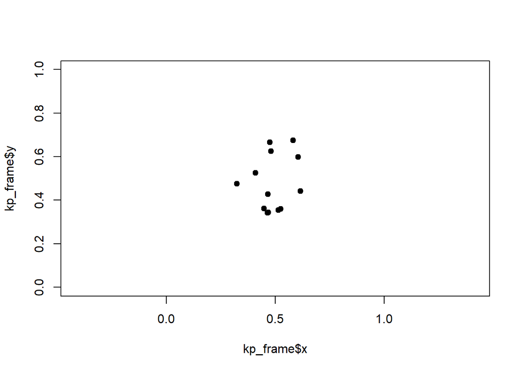

```r
plot(x = kp_frame$x,
     y = kp_frame$y,
     xlim = c(0, 1),
     ylim = c(0, 1),
     asp = 1,
     pch = 19)
```

Okay, this does not look very helpful yet. Let’s add lines between some of the key points to create an image that is closer to the one we’ve seen on the slides earlier.

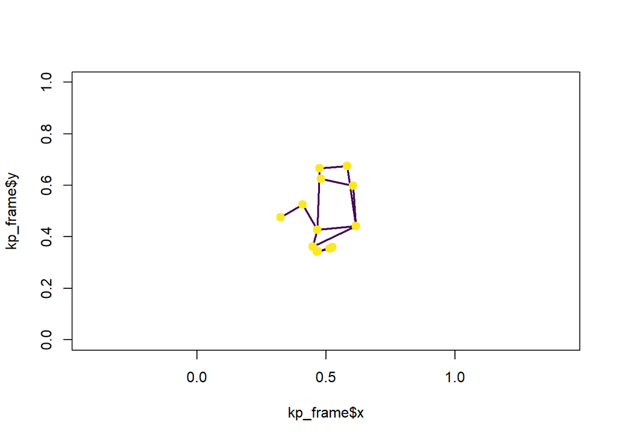

```r
# this list stores all key points we would like to connect

edges <- list(c(1, 2),    # nose - left eye
              c(1, 3),    # nose - right eye
              c(2, 4),    # left eye - left ear
              c(3, 5),    # right eye - right ear
              c(1, 6),    # nose - left shoulder
              c(1, 7),    # nose - right shoulder
              c(6, 8),    # left shoulder - left elbow
              c(8, 10),   # left elbow - left wrist
              c(7, 9),    # right shoulder - right elbow
              c(9, 11),   # right elbow - right wrist
              c(6, 7),    # left shoulder - right shoulder
              c(6, 12),   # left shoulder - left hip
              c(7, 13),   # right shoulder - right hip
              c(12, 13),  # left hip - right hip
              c(12, 14),  # left hip - left knee
              c(14, 16),  # left knee - left ankle
              c(13, 15),  # right hip - right knee
              c(15, 17))  # right knee - right ankle


# 1) We start with an empty plot:
plot(x = kp_frame$x,
     y = kp_frame$y,
     type = "n",
     xlim = c(0, 1),
     ylim = c(0, 1),
     asp = 1)

# 2) Next, we add all lines to the plot:
for (e in 1:length(edges)) {
  p1 <- kp_frame[edges[[e]][1], c("x", "y")]
  p2 <- kp_frame[edges[[e]][2], c("x", "y")]

  if (all(!is.na(p1)) & all(!is.na(p2))) {
    segments(
      x0 = as.numeric(p1$x),
      y0 = as.numeric(p1$y),
      x1 = as.numeric(p2$x),
      y1 = as.numeric(p2$y),
      lwd = 2,
      col = viridis(2)[1]
    )
  }
}

# 3) And add the key points on top:
points(x = kp_frame$x,
       y = kp_frame$y,
       pch = 19,
       cex = 1.25,
       col = viridis(2)[2])
```

This looks better, but the figure is upside down. Why? Because, as we’ve seen earlier, the y-axis is reversed. We can fix this quite easily by adjusting `ylim`:

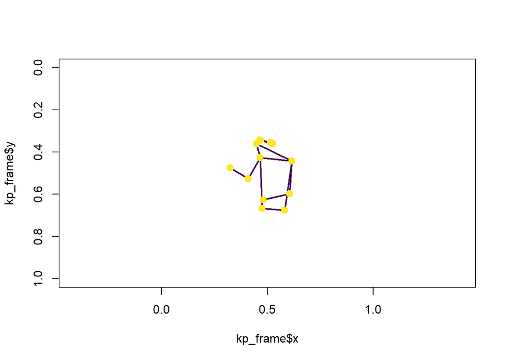

```r
plot(x = kp_frame$x,
     y = kp_frame$y,
     type = "n",
     xlim = c(0, 1),
     ylim = c(1, 0), # changing this from c(0,1) to c(1,0) fixes the y-axis
     asp = 1,)


# The rest of the code remains the same:

for (e in 1:length(edges)) {
  p1 <- kp_frame[edges[[e]][1], c("x", "y")]
  p2 <- kp_frame[edges[[e]][2], c("x", "y")]

  if (all(!is.na(p1)) & all(!is.na(p2))) {
    segments(
      x0 = as.numeric(p1$x),
      y0 = as.numeric(p1$y),
      x1 = as.numeric(p2$x),
      y1 = as.numeric(p2$y),
      lwd = 2,
      col = viridis(2)[1]
    )
  }
}

points(x = kp_frame$x,
       y = kp_frame$y,
       pch = 19,
       cex = 1.25,
       col = viridis(2)[2])
```

This looks more like what we envisioned. We can also look at the frame and the key point representation side by side:

[figure not shown]

```r
# create two columns
par(mfrow = c(1, 2))

# plot the frame:
plot(image,
       axes = T)

# plot the key point representation
plot(x = kp_frame$x,
     y = kp_frame$y,
     asp = 1,
     xlim = c(0, 1),
     ylim = c(1, 0), # changing this from c(0,1) to c(1,0) fixes the y-axis
     axes = T,
     xlab = "",
     ylab = "",
     bty = "n")


for (e in 1:length(edges)) {
  p1 <- kp_frame[edges[[e]][1], c("x", "y")]
  p2 <- kp_frame[edges[[e]][2], c("x", "y")]

  if (all(!is.na(p1)) & all(!is.na(p2))) {
    segments(
      x0 = as.numeric(p1$x),
      y0 = as.numeric(p1$y),
      x1 = as.numeric(p2$x),
      y1 = as.numeric(p2$y),
      lwd = 2,
      col = viridis(2)[1]
    )
  }
}

points(x = kp_frame$x,
       y = kp_frame$y,
       pch = 19,
       cex = 1.25,
       col = viridis(2)[2])
```

Or, we can plot the key points on top of the frame. To do so, we need to rescale the key points. The key-points are scaled between zero and one, whereas our image are scaled according to their pixel size, i.e. 720x400.

These two functions will rescale the x- and y-values of our key point representations so that they match the scale of the frame:

```r
scale_x <- function(x, x_size){x*x_size}
scale_y <- function(y, x_size, y_size){y*x_size-((x_size-y_size)/2)}

kp_frame$x_scaled <- scale_x(x = kp_frame$x, x_size = x_size)
kp_frame$y_scaled <- scale_y(y = kp_frame$y, x_size = x_size, y_size = y_size)
```

[figure not shown]

```r
plot(image,
     axes = F)

for (e in 1:length(edges)) {
  p1 <- kp_frame[edges[[e]][1], c("x_scaled", "y_scaled")]
  p2 <- kp_frame[edges[[e]][2], c("x_scaled", "y_scaled")]

  if (all(!is.na(p1)) & all(!is.na(p2))) {
    segments(
      x0 = as.numeric(p1$x),
      y0 = as.numeric(p1$y),
      x1 = as.numeric(p2$x),
      y1 = as.numeric(p2$y),
      lwd = 2,
      col = viridis(2)[1]
    )
  }
}

points(x = kp_frame$x_scaled,
       y = kp_frame$y_scaled,
       pch = 19,
       cex = 1.25,
       col = viridis(2)[2])
```

I hope visualizing individual frames gave you a feeling for the data. We now proceed to calculating our two body language indicators from time series of key point representations. That is, we will calculate our indicator of gesticulation and our measure of posture for both speech sequences.

# Calculate measure of gesticulation

Let’s recall how we would like to quantify the level of gesticulation shown by the speaker. We defined gesticulation as dynamic use of gestures, specifically through hand movement. We will make use of the fact that hand movement is captured by the distances of hand locations between frames. The more a speaker moves their hands, the higher the distance of hand locations between two consecutive frames. We construct our **measure of gesticulation** as the **average between-frame distance of the speaker’s left and right hand**.

To calculate between-frame distances of key points, we need a function to calculate euclidean distances:

```r
euclidean_distance <- function(x1, y1, x2, y2){
  dist <- sqrt((x2-x1)^2 + (y2-y1)^2)
  return(dist)
}
```

With this function at hand, we can code a function that calculates the distances of the left and right wrists between all frames of a video sequence:

```r
calculate_wrist_movement <- function(kp_data){

  # LEFT WRIST (kp10)
  kp_data$left_wrist_movement <-
      euclidean_distance(x1 = kp_data$kp10_x,
                         y1 = kp_data$kp10_y,
                         x2 = lead(kp_data$kp10_x),
                         y2 = lead(kp_data$kp10_y))

  # RIGHT WRIST (kp11)
  kp_data$right_wrist_movement <-
      euclidean_distance(x1 = kp_data$kp11_x,
                         y1 = kp_data$kp11_y,
                         x2 = lead(kp_data$kp11_x),
                         y2 = lead(kp_data$kp11_y))

  return(kp_data)
}
```

Let’s apply the function to both speeches

```r
speech1_keypoints <- calculate_wrist_movement(speech1_keypoints)
speech2_keypoints <- calculate_wrist_movement(speech2_keypoints)
```

The function added variables for left and right wrist movement

```r
head(speech1_keypoints[, c("left_wrist_movement", "right_wrist_movement")])
```

```
##   left_wrist_movement right_wrist_movement
## 1         0.007190624         0.0026941678
## 2         0.006933159         0.0021304339
## 3         0.004113916         0.0004935446
## 4         0.003140460         0.0005178051
## 5         0.005515408         0.0034044976
## 6         0.001626312         0.0041811225
```

```r
head(speech2_keypoints[, c("left_wrist_movement", "right_wrist_movement")])
```

```
##   left_wrist_movement right_wrist_movement
## 1        0.0078175540          0.017903471
## 2        0.0005784549          0.022548839
## 3        0.0040205017          0.011768234
## 4        0.0004598332          0.001570991
## 5        0.0034531529          0.007260658
## 6        0.0034903135          0.026569880
```

All left to do is to calculate the average movement of the left and right wrist:

```r
# Gesticulation speech 1
mean(c(speech1_keypoints$left_wrist_movement,
       speech1_keypoints$right_wrist_movement),
     na.rm = T)
```

```
## [1] 0.00428086
```

```r
# Gesticulation speech 2
mean(c(speech2_keypoints$left_wrist_movement,
       speech2_keypoints$right_wrist_movement),
     na.rm = T)
```

```
## [1] 0.01500968
```

# Calculate measure of posture

```r
calculate_wrist_height <- function(kp_data){

  # left shoulder: kp6
  # left wrist: kp10
  # right shoulder: kp7
  # right wrist: kp11

  # left height:
  kp_data$left_wrist_height <- kp_data$kp6_y - kp_data$kp10_y

  # right wrist height:
  kp_data$right_wrist_height <- kp_data$kp7_y - kp_data$kp11_y

  # height of the higher wrist
  kp_data$max_wrist_height <-
    apply(kp_data[, c("left_wrist_height", "right_wrist_height")], 1, max)

  return(kp_data)
}
```

```r
speech1_keypoints <- calculate_wrist_height(speech1_keypoints)
speech2_keypoints <- calculate_wrist_height(speech2_keypoints)
```

```r
mean(speech1_keypoints$max_wrist_height)
```

```
## [1] -0.2037267
```

```r
mean(speech2_keypoints$max_wrist_height)
```

```
## [1] -0.05291393
```